# An anti-inflammatory response of an organic food intervention treatment by reducing pesticide exposures in children of Cyprus: a cluster-randomized crossover trial - Part 2

# Regression analysis (mixed effects models)

This script includes the regression analysis (Part 2). The output of the Part 1 script needs to be created (produced_data/meas1).

## Visualization

Visualize the association between the creatinine adjusted crp measurements and the time and the non creatinine crp adjusted measurements and the days from treatment.

- Both measurements (creatinine adjusted crp and non creatinine adjusted crp) are log transformed.

**Plot 1. Association between the CRP measurements (adjusted and non adjusted) and the days from treatment for the organic phase**

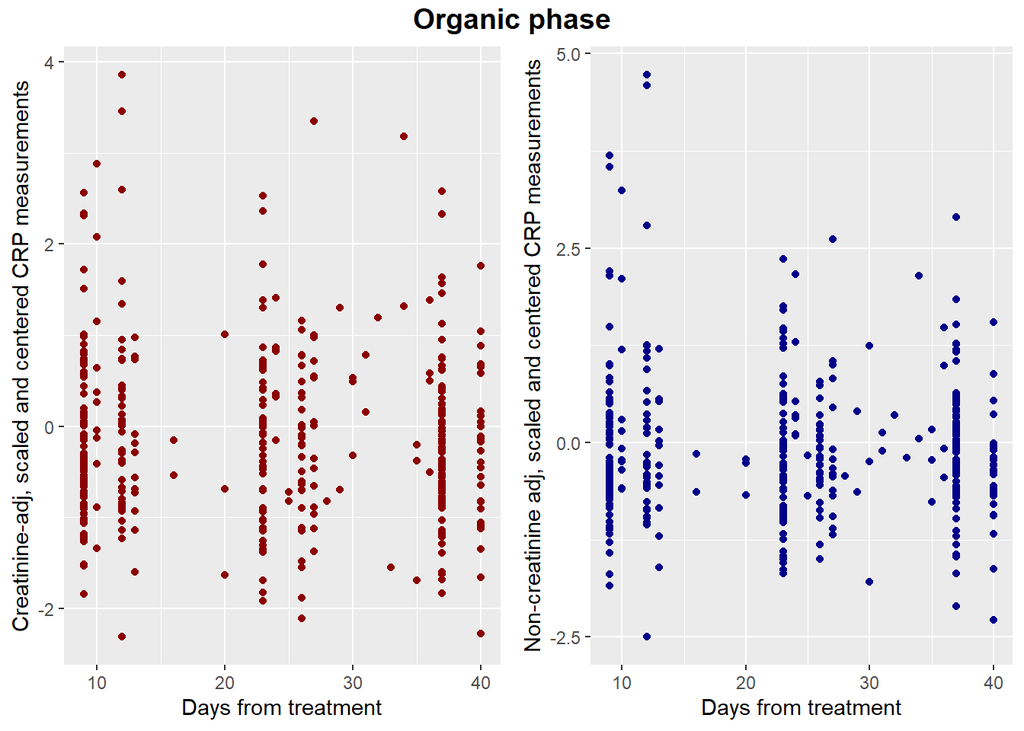

**Plot 2. Association between the CRP measurements (adjusted and non adjusted) and the days from treatment for the conventional phase**

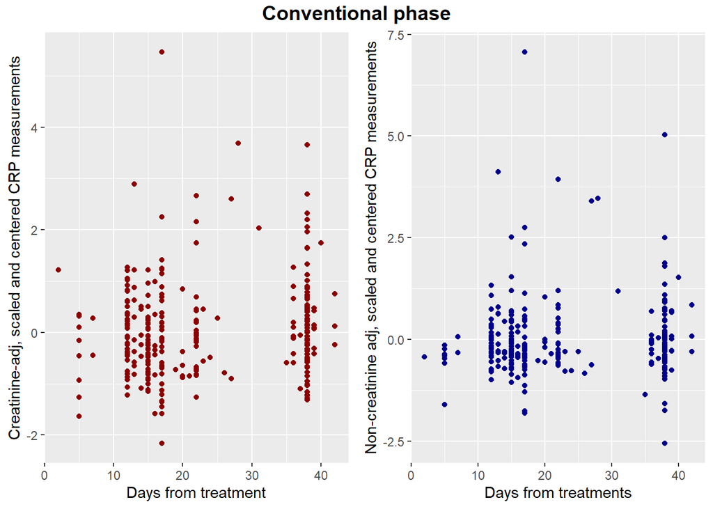

**Plot 3. Association between the creatinine adjusted CRP measurements and the days from treatment for each phase**

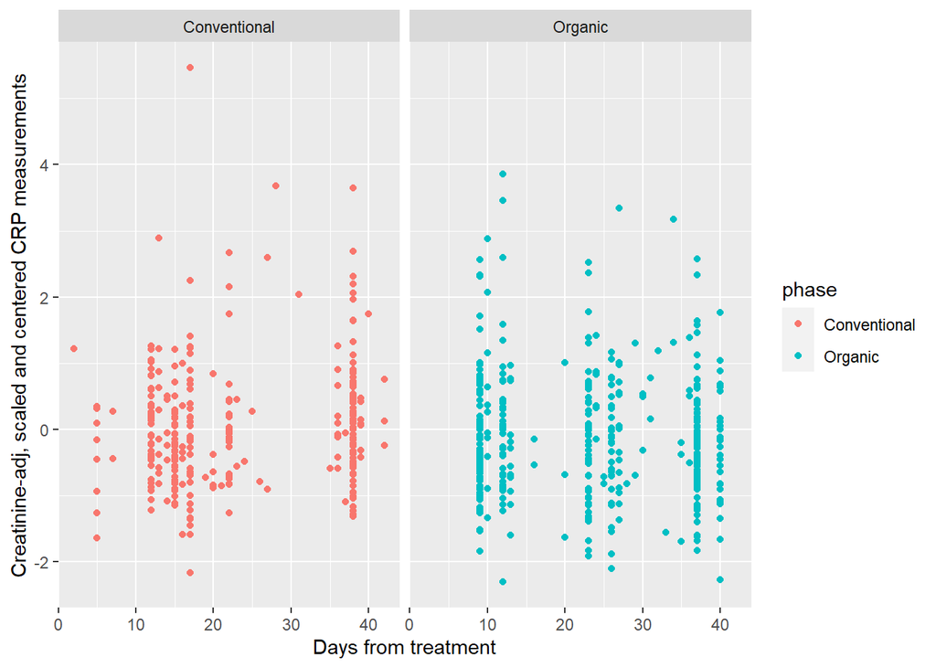

**Plot 4. Association between the non-creatinine adjusted CRP measurements and the days from treatment for each phase**

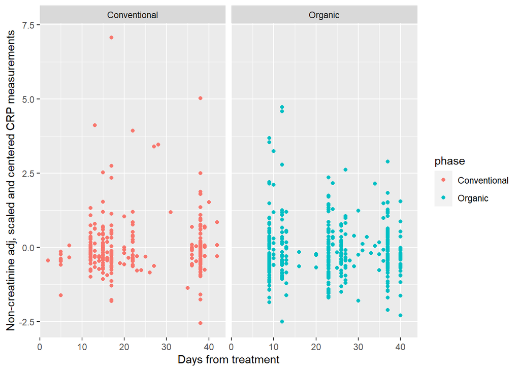

## Main analysis

All models were adjusted for the baseline value of the outcome.

All models were adjusted for the creatinine levels using two ways:

- CRP and pesticides measurements were divided with the respective creatinine measurements
- Creatinine was included as a fixed effect

Initial model (model for objective 1):

- Random part: participants
- Fixed effect: treatment condition (organic or conventional) and time (days of treatment, where time=0 was the start of the treatment)
- Interaction term: time*phase
- Check interaction term:
- if p-value>0.05 remove from the model

### Log creatinine adjusted CRP ~ baseline log creatinine adjusted CRP + DaysfromTreatment + phase + (phase*DaysfromTreatment if p<0.05) + random(…)

**Initial model (including the interaction term)**

logadj_crp_S_BL + DaysfromTreatment + phase + DaysfromTreatment * phase + (1 | ID)

|  | logadj crp S TR |  |  |
| --- | --- | --- | --- |
| Predictors | Estimates | CI | p |
| (Intercept) | -0.263 | -0.514 – -0.013 | **0.040** |
| logadj crp S BL | 0.040 | -0.037 – 0.116 | 0.314 |
| DaysfromTreatment | 0.012 | 0.003 – 0.022 | **0.011** |
| phase [Organic] | 0.299 | -0.013 – 0.610 | 0.060 |
| DaysfromTreatment × phase [Organic] | -0.019 | -0.031 – -0.006 | **0.003** |
| Random Effects |  |  |  |
| σ<sup>2</sup> | 0.74 |  |  |
| τ<sub>00</sub> <sub>ID</sub> | 0.16 |  |  |
| ICC | 0.17 |  |  |
| N <sub>ID</sub> | 147 |  |  |
| Observations | 682 |  |  |
| Marginal R<sup>2</sup> / Conditional R<sup>2</sup> | 0.019 / 0.190 |  |  |

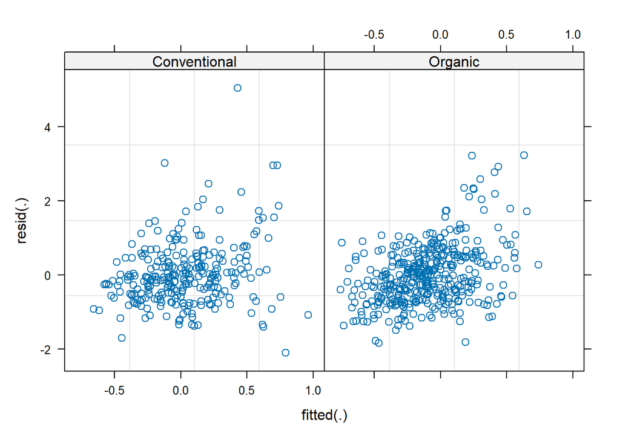

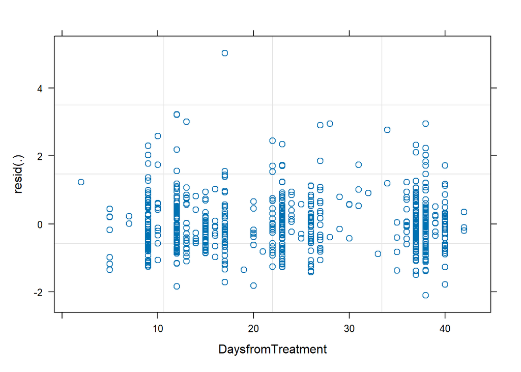

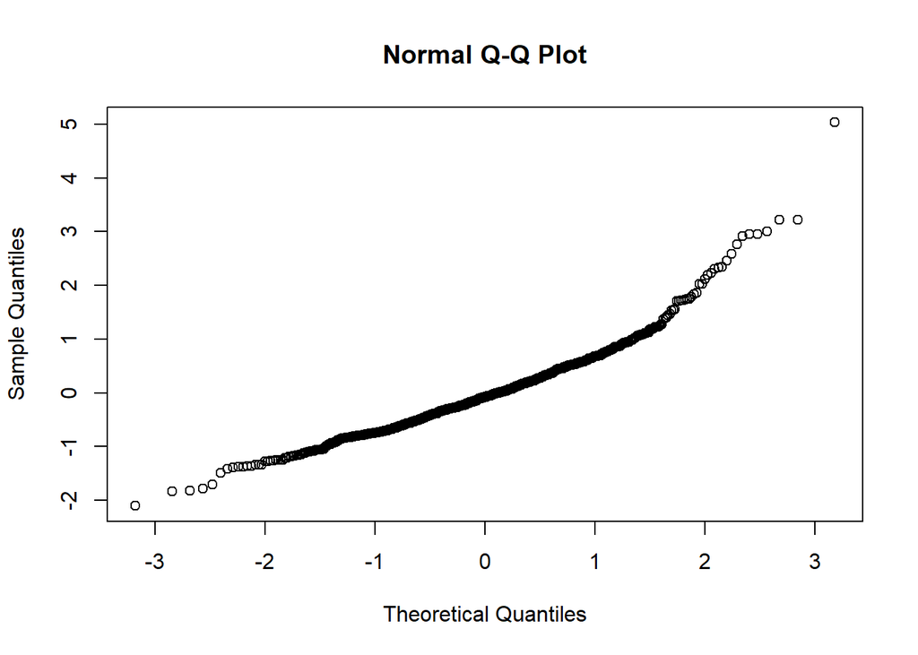

### Log CRP ~ baseline Log CRP + DaysfromTreatment + phase + creatinine_S + (phase*DaysfromTreatment if p<0.05) + random(…)

logcrp_S_BL + DaysfromTreatment + phase + creatinine_S + phase * DaysfromTreatment + (1 | ID)

|  | logcrp S TR |  |  |
| --- | --- | --- | --- |
| Predictors | Estimates | CI | p |
| (Intercept) | -0.097 | -0.351 – 0.157 | 0.453 |
| logcrp S BL | 0.022 | -0.045 – 0.089 | 0.519 |
| DaysfromTreatment | 0.005 | -0.005 – 0.015 | 0.323 |
| phase [Organic] | 0.097 | -0.224 – 0.419 | 0.553 |
| creatinine S | 0.063 | -0.011 – 0.136 | 0.095 |
| DaysfromTreatment × phase [Organic] | -0.008 | -0.021 – 0.004 | 0.197 |
| Random Effects |  |  |  |
| σ<sup>2</sup> | 0.79 |  |  |
| τ<sub>00</sub> <sub>ID</sub> | 0.09 |  |  |
| ICC | 0.10 |  |  |
| N <sub>ID</sub> | 147 |  |  |
| Observations | 682 |  |  |
| Marginal R<sup>2</sup> / Conditional R<sup>2</sup> | 0.009 / 0.108 |  |  |

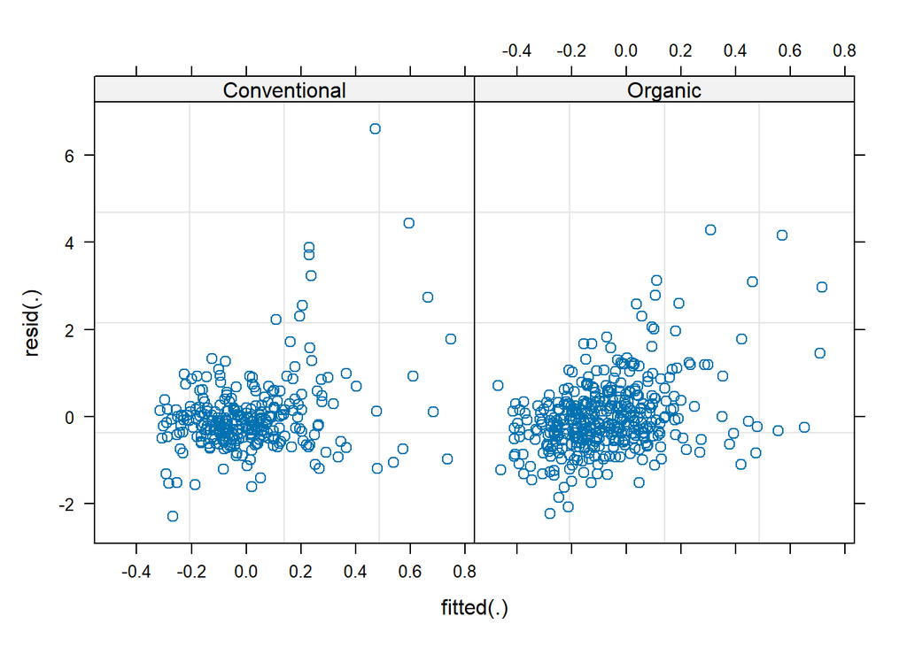

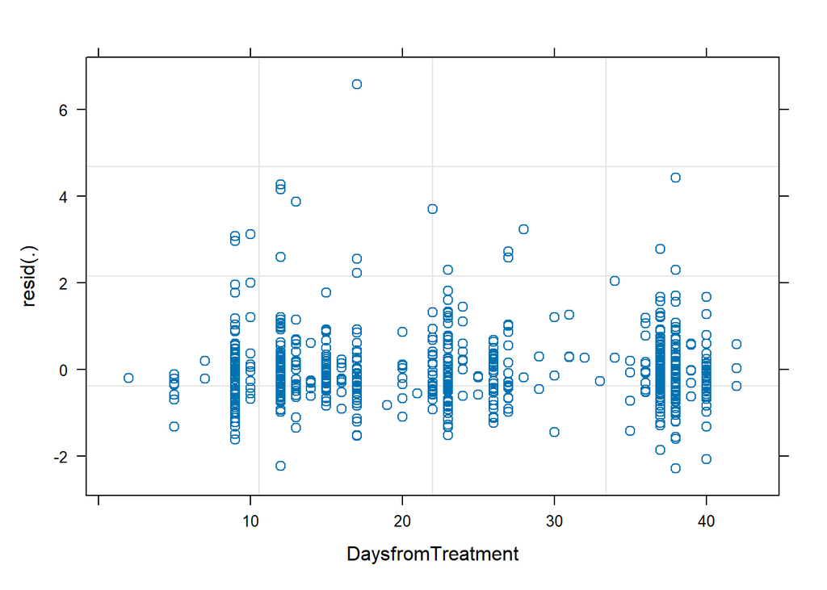

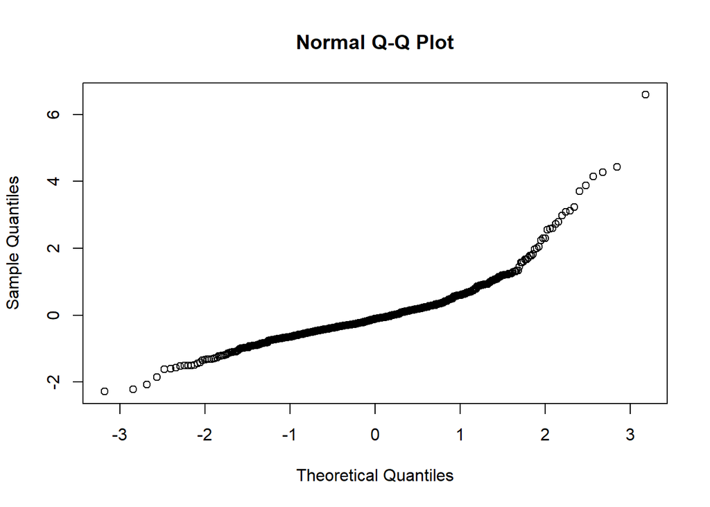

logcrp_S_BL + DaysfromTreatment + phase + creatinine_S + (1 | ID)

|  | logcrp S TR |  |  |
| --- | --- | --- | --- |
| Predictors | Estimates | CI | p |
| (Intercept) | 0.020 | -0.161 – 0.201 | 0.827 |
| logcrp S BL | 0.022 | -0.044 – 0.089 | 0.510 |
| DaysfromTreatment | -0.000 | -0.006 – 0.006 | 0.960 |
| phase [Organic] | -0.094 | -0.232 – 0.043 | 0.177 |
| creatinine S | 0.056 | -0.016 – 0.129 | 0.129 |
| Random Effects |  |  |  |
| σ<sup>2</sup> | 0.79 |  |  |
| τ<sub>00</sub> <sub>ID</sub> | 0.09 |  |  |
| ICC | 0.10 |  |  |
| N <sub>ID</sub> | 147 |  |  |
| Observations | 682 |  |  |
| Marginal R<sup>2</sup> / Conditional R<sup>2</sup> | 0.007 / 0.106 |  |  |

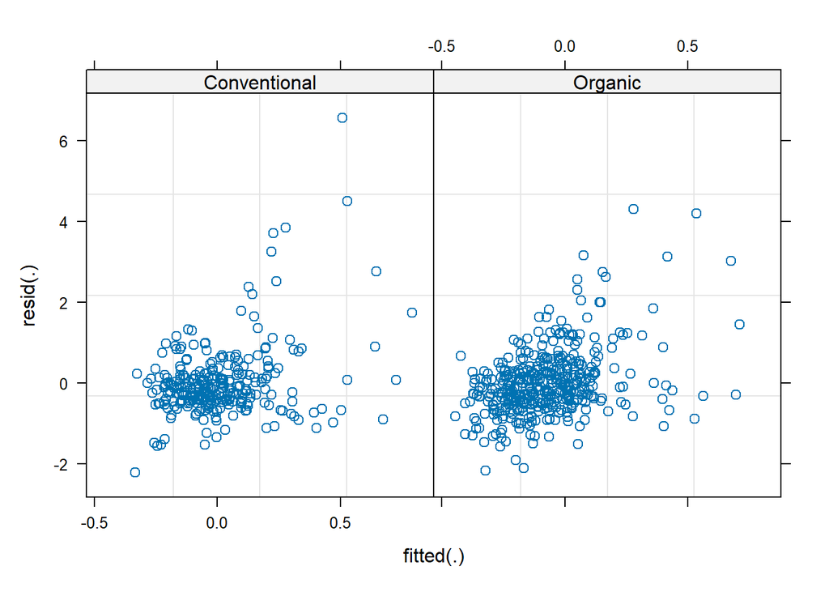

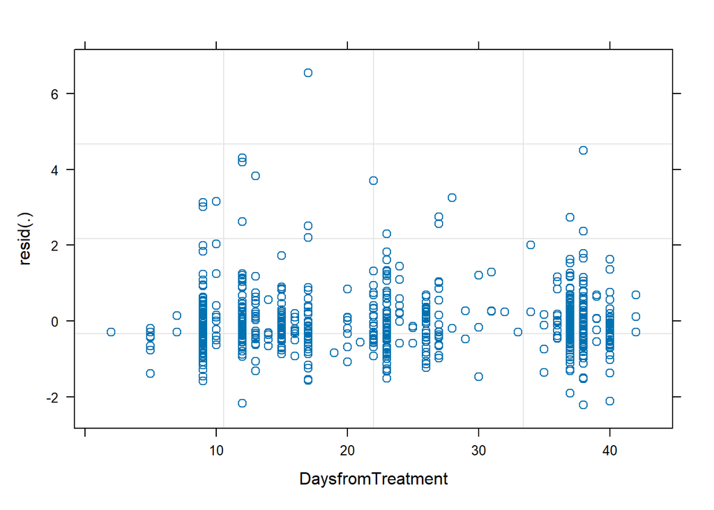

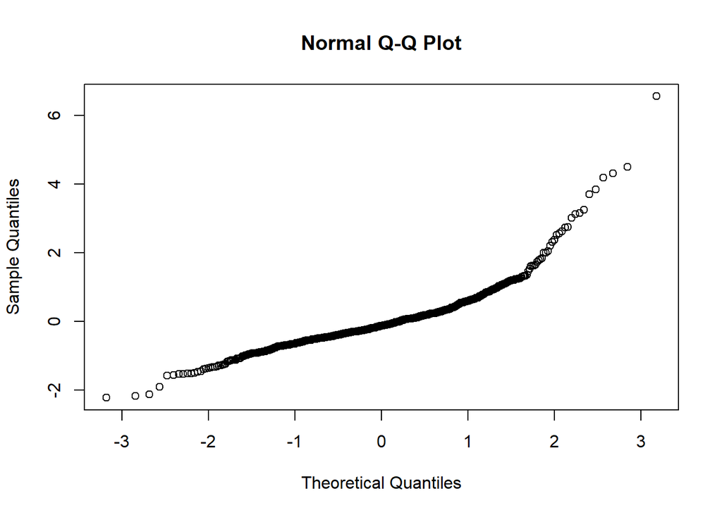

### Merge the models of objective 1

Merge the models of objective 1

|  | logadj crp S TR |  |  | logcrp S TR |  |  |
| --- | --- | --- | --- | --- | --- | --- |
| Predictors | Estimates | CI | p | Estimates | CI | p |
| (Intercept) | -0.263 | -0.514 – -0.013 | **0.040** | 0.020 | -0.161 – 0.201 | 0.827 |
| logadj crp S BL | 0.040 | -0.037 – 0.116 | 0.314 |  |  |  |
| DaysfromTreatment | 0.012 | 0.003 – 0.022 | **0.011** | -0.000 | -0.006 – 0.006 | 0.960 |
| phase [Organic] | 0.299 | -0.013 – 0.610 | 0.060 | -0.094 | -0.232 – 0.043 | 0.177 |
| DaysfromTreatment × phase [Organic] | -0.019 | -0.031 – -0.006 | **0.003** |  |  |  |
| logcrp S BL |  |  |  | 0.022 | -0.044 – 0.089 | 0.510 |
| creatinine S |  |  |  | 0.056 | -0.016 – 0.129 | 0.129 |
| Random Effects |  |  |  |  |  |  |
| σ<sup>2</sup> | 0.74 |  |  | 0.79 |  |  |
| τ<sub>00</sub> | 0.16 <sub>ID</sub> |  |  | 0.09 <sub>ID</sub> |  |  |
| ICC | 0.17 |  |  | 0.10 |  |  |
| N | 147 <sub>ID</sub> |  |  | 147 <sub>ID</sub> |  |  |
| Observations | 682 |  |  | 682 |  |  |
| Marginal R<sup>2</sup> / Conditional R<sup>2</sup> | 0.019 / 0.190 |  |  | 0.007 / 0.106 |  |  |

## Model requested by Associate Editor

### Log CRP ~ baseline Log CRP + DaysfromTreatment + phase + log_creatinine + (phase*DaysfromTreatment if p<0.05) + random(…)

logcrp_S_BL + DaysfromTreatment + phase + logcr_S + phase * DaysfromTreatment + (1 | ID)

|  | logcrp S TR |  |  |
| --- | --- | --- | --- |
| Predictors | Estimates | CI | p |
| (Intercept) | -0.097 | -0.351 – 0.158 | 0.456 |
| logcrp S BL | 0.022 | -0.044 – 0.089 | 0.508 |
| DaysfromTreatment | 0.005 | -0.005 – 0.015 | 0.332 |
| phase [Organic] | 0.096 | -0.226 – 0.418 | 0.559 |
| logcr S | 0.057 | -0.016 – 0.131 | 0.128 |
| DaysfromTreatment × phase [Organic] | -0.008 | -0.021 – 0.004 | 0.207 |
| Random Effects |  |  |  |
| σ<sup>2</sup> | 0.79 |  |  |
| τ<sub>00</sub> <sub>ID</sub> | 0.09 |  |  |
| ICC | 0.10 |  |  |
| N <sub>ID</sub> | 147 |  |  |
| Observations | 682 |  |  |
| Marginal R<sup>2</sup> / Conditional R<sup>2</sup> | 0.009 / 0.107 |  |  |

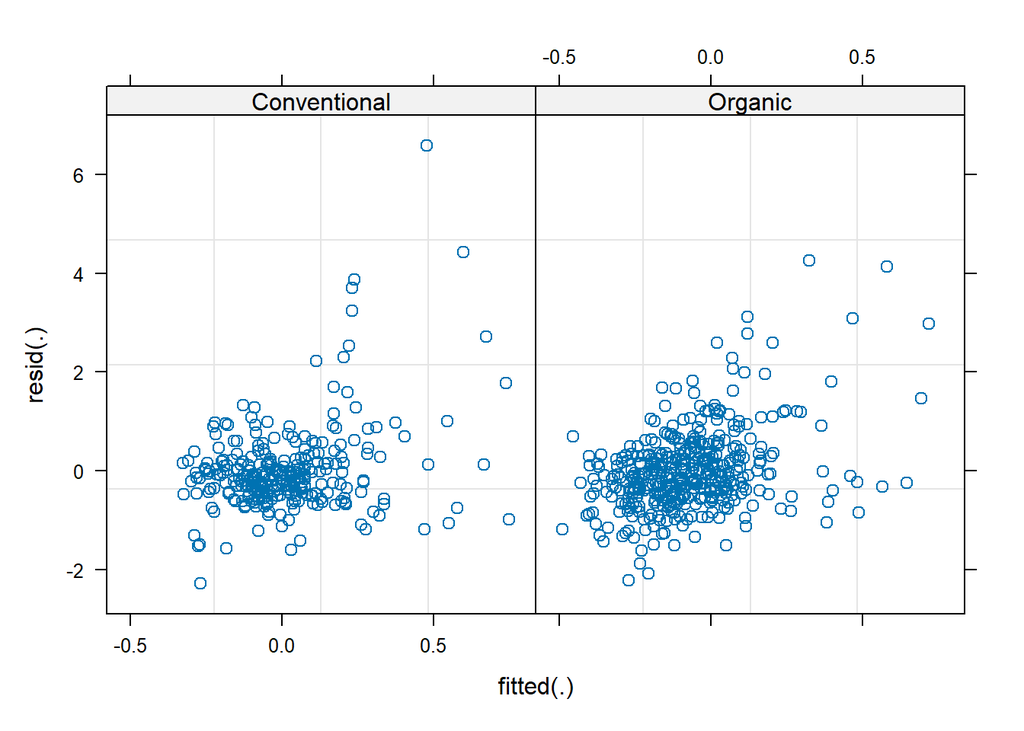

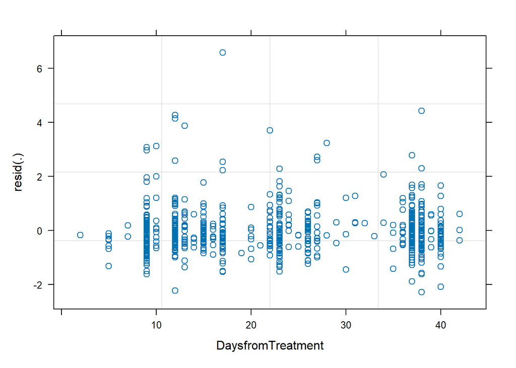

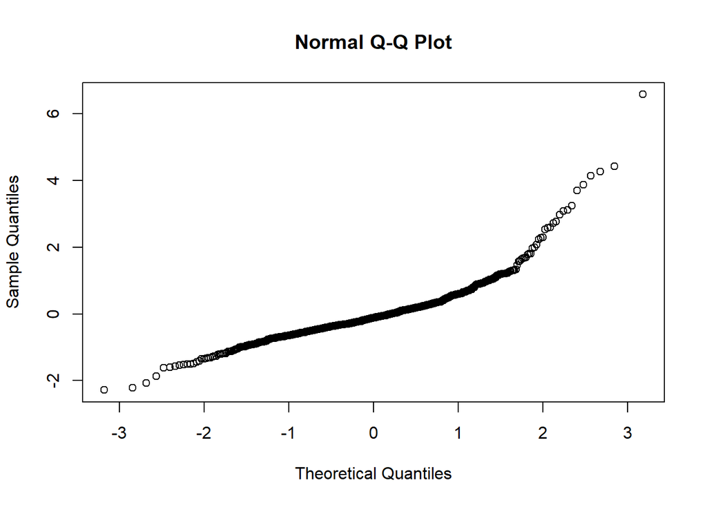

logcrp_S_BL + DaysfromTreatment + phase + logcr_S + (1 | ID)

|  | logcrp S TR |  |  |
| --- | --- | --- | --- |
| Predictors | Estimates | CI | p |
| (Intercept) | 0.018 | -0.163 – 0.199 | 0.843 |
| logcrp S BL | 0.023 | -0.044 – 0.090 | 0.501 |
| DaysfromTreatment | -0.000 | -0.006 – 0.006 | 0.966 |
| phase [Organic] | -0.092 | -0.229 – 0.045 | 0.190 |
| logcr S | 0.052 | -0.022 – 0.125 | 0.167 |
| Random Effects |  |  |  |
| σ<sup>2</sup> | 0.79 |  |  |
| τ<sub>00</sub> <sub>ID</sub> | 0.09 |  |  |
| ICC | 0.10 |  |  |
| N <sub>ID</sub> | 147 |  |  |
| Observations | 682 |  |  |
| Marginal R<sup>2</sup> / Conditional R<sup>2</sup> | 0.006 / 0.106 |  |  |

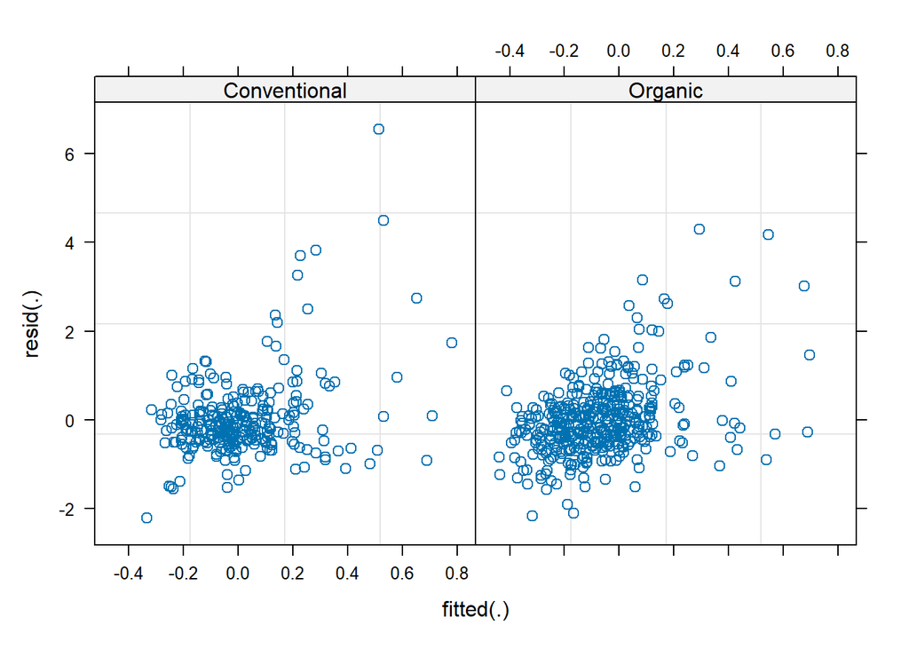

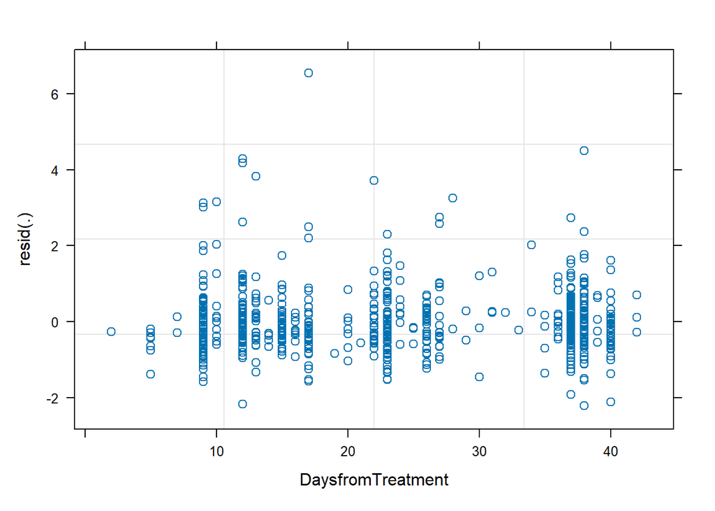

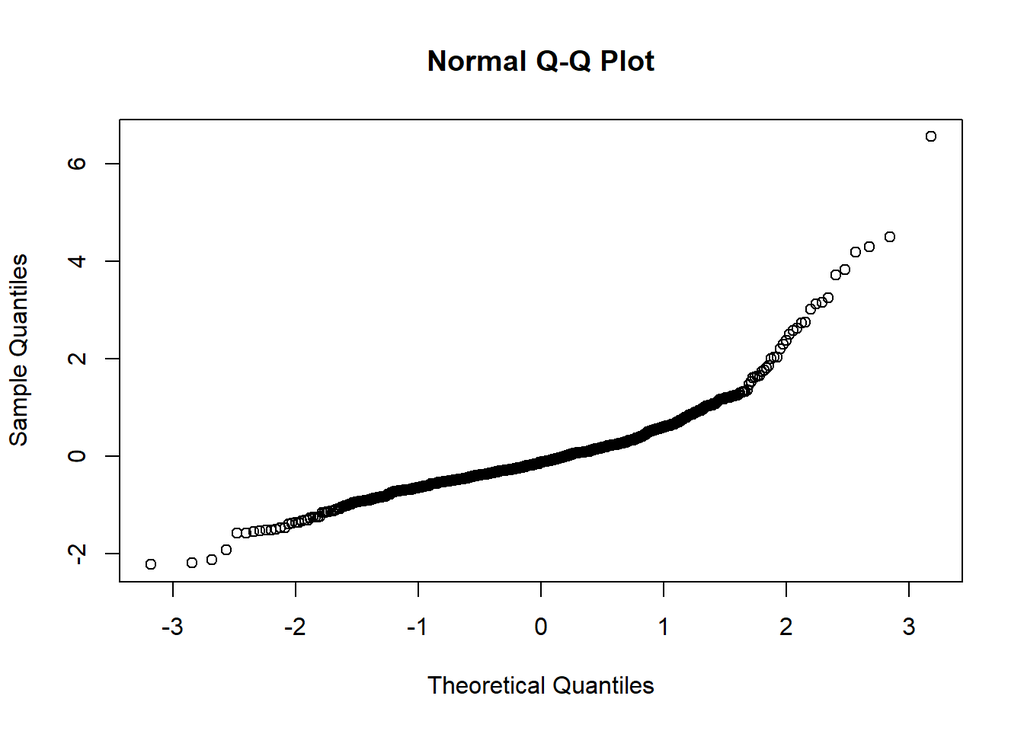

### Models for objective 2

A second model was made to assess the association between biomarker of exposure to pesticides (3-PBA and 6-CN, separately) and biomarker of inflammation (CRP).

- Random part: participants
- Fixed effect: each biomarker of exposure to pesticides, time (days of treatment, where time=0 was the start of the treatment), age and sex

### Log creatinine adjusted CRP ~ Log creatinine adjusted baseline CRP + 6-CN (binary) + DaysfromTreatment + sex + baseline age + random(…)

logadj_crp_S_BL + cnlod + DaysfromTreatment + Sex + age_baseline_S + (1 | ID)

|  | logadj crp S TR |  |  |
| --- | --- | --- | --- |
| Predictors | Estimates | CI | p |
| (Intercept) | -0.092 | -0.286 – 0.101 | 0.349 |
| logadj crp S BL | 0.036 | -0.043 – 0.115 | 0.368 |
| cnlod [Above LOD] | 0.025 | -0.134 – 0.183 | 0.761 |
| DaysfromTreatment | 0.001 | -0.005 – 0.007 | 0.817 |
| Sex [Female] | 0.028 | -0.158 – 0.213 | 0.768 |
| age baseline S | -0.009 | -0.102 – 0.084 | 0.851 |
| Random Effects |  |  |  |
| σ<sup>2</sup> | 0.76 |  |  |
| τ<sub>00</sub> <sub>ID</sub> | 0.16 |  |  |
| ICC | 0.17 |  |  |
| N <sub>ID</sub> | 146 |  |  |
| Observations | 681 |  |  |
| Marginal R<sup>2</sup> / Conditional R<sup>2</sup> | 0.003 / 0.172 |  |  |

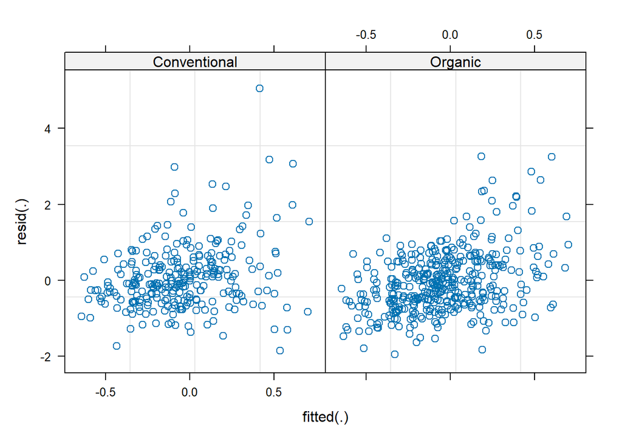

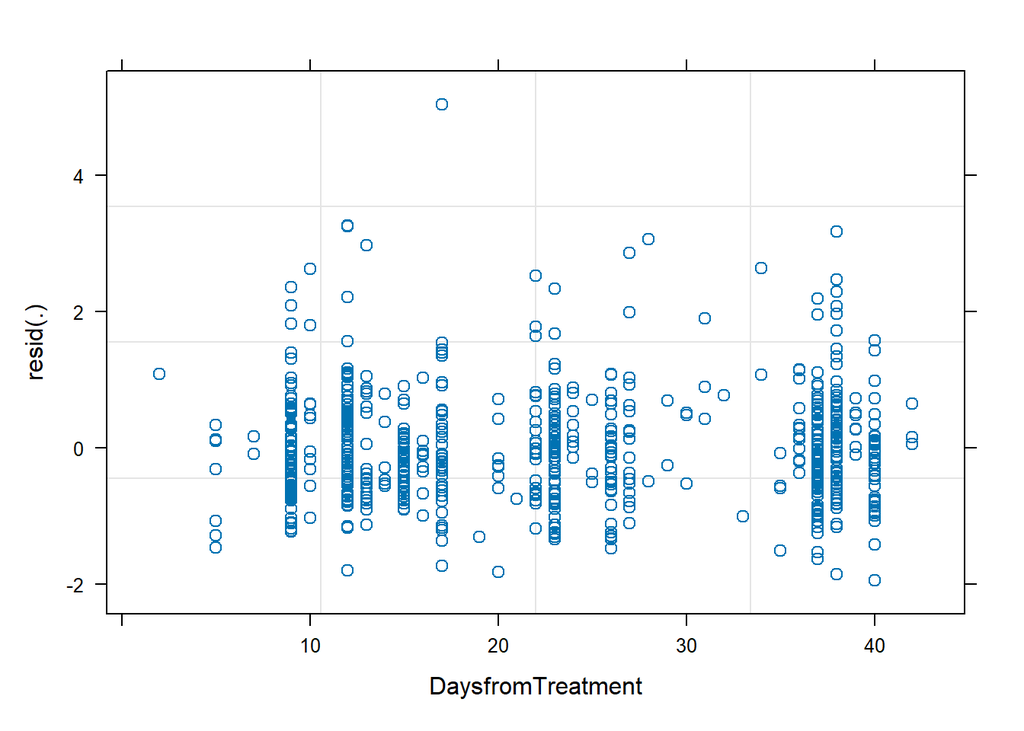

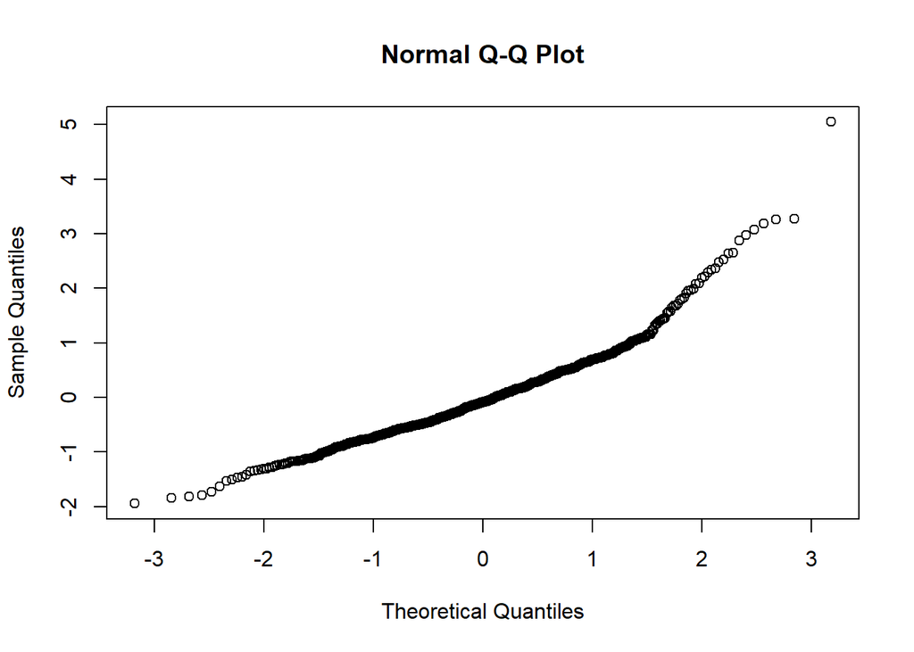

### Log CRP ~ log baseline CRP + 6-CN + DaysfromTreatment + sex + baseline age + creatinine_s + random(…)

logcrp_S_BL + cnlod + DaysfromTreatment + Sex + age_baseline_S + creatinine_S + (1 | ID)

|  | logcrp S TR |  |  |
| --- | --- | --- | --- |
| Predictors | Estimates | CI | p |
| (Intercept) | -0.005 | -0.194 – 0.184 | 0.962 |
| logcrp S BL | 0.021 | -0.047 – 0.089 | 0.541 |
| cnlod [Above LOD] | 0.017 | -0.143 – 0.176 | 0.838 |
| DaysfromTreatment | -0.000 | -0.006 – 0.006 | 0.935 |
| Sex [Female] | -0.070 | -0.237 – 0.098 | 0.415 |
| age baseline S | -0.006 | -0.091 – 0.078 | 0.881 |
| creatinine S | 0.051 | -0.022 – 0.124 | 0.171 |
| Random Effects |  |  |  |
| σ<sup>2</sup> | 0.80 |  |  |
| τ<sub>00</sub> <sub>ID</sub> | 0.09 |  |  |
| ICC | 0.10 |  |  |
| N <sub>ID</sub> | 146 |  |  |
| Observations | 681 |  |  |
| Marginal R<sup>2</sup> / Conditional R<sup>2</sup> | 0.006 / 0.106 |  |  |

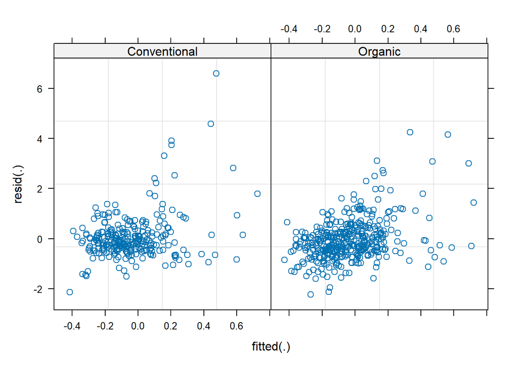

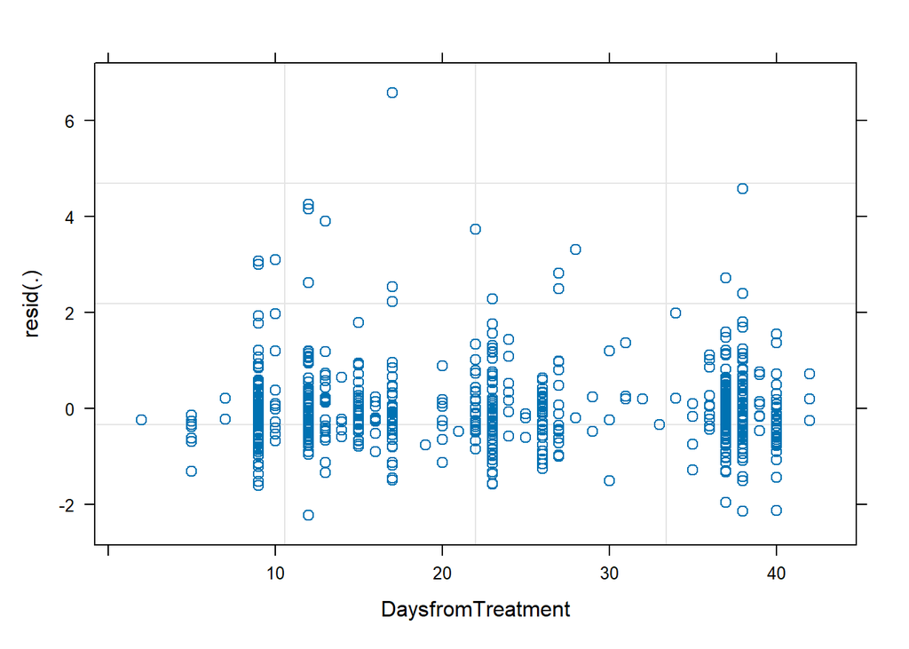

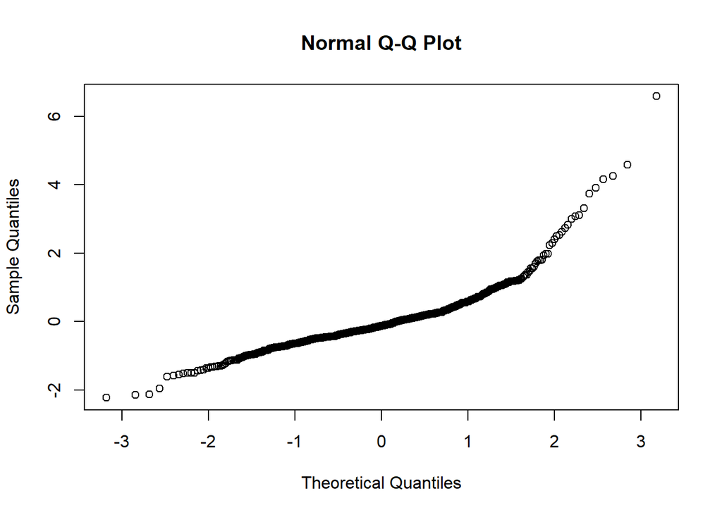

### Merge the models of objective 2-6-CN

Merge the models of objective 2-6-CN

|  | logadj crp S TR |  |  | logcrp S TR |  |  |
| --- | --- | --- | --- | --- | --- | --- |
| Predictors | Estimates | CI | p | Estimates | CI | p |
| (Intercept) | -0.092 | -0.286 – 0.101 | 0.349 | -0.005 | -0.194 – 0.184 | 0.962 |
| logadj crp S BL | 0.036 | -0.043 – 0.115 | 0.368 |  |  |  |
| cnlod [Above LOD] | 0.025 | -0.134 – 0.183 | 0.761 | 0.017 | -0.143 – 0.176 | 0.838 |
| DaysfromTreatment | 0.001 | -0.005 – 0.007 | 0.817 | -0.000 | -0.006 – 0.006 | 0.935 |
| Sex [Female] | 0.028 | -0.158 – 0.213 | 0.768 | -0.070 | -0.237 – 0.098 | 0.415 |
| age baseline S | -0.009 | -0.102 – 0.084 | 0.851 | -0.006 | -0.091 – 0.078 | 0.881 |
| logcrp S BL |  |  |  | 0.021 | -0.047 – 0.089 | 0.541 |
| creatinine S |  |  |  | 0.051 | -0.022 – 0.124 | 0.171 |
| Random Effects |  |  |  |  |  |  |
| σ<sup>2</sup> | 0.76 |  |  | 0.80 |  |  |
| τ<sub>00</sub> | 0.16 <sub>ID</sub> |  |  | 0.09 <sub>ID</sub> |  |  |
| ICC | 0.17 |  |  | 0.10 |  |  |
| N | 146 <sub>ID</sub> |  |  | 146 <sub>ID</sub> |  |  |
| Observations | 681 |  |  | 681 |  |  |
| Marginal R<sup>2</sup> / Conditional R<sup>2</sup> | 0.003 / 0.172 |  |  | 0.006 / 0.106 |  |  |

## Model requested by Associate Editor

### Log CRP ~ log baseline CRP + 6-CN + DaysfromTreatment + sex + baseline age + log-creatinine_s + random(…)

logcrp_S_BL + cnlod + DaysfromTreatment + Sex + age_baseline_S + logcr_S + (1 | ID)

|  | logcrp S TR |  |  |
| --- | --- | --- | --- |
| Predictors | Estimates | CI | p |
| (Intercept) | -0.004 | -0.193 – 0.185 | 0.965 |
| logcrp S BL | 0.022 | -0.046 – 0.090 | 0.530 |
| cnlod [Above LOD] | 0.015 | -0.144 – 0.175 | 0.850 |
| DaysfromTreatment | -0.000 | -0.006 – 0.006 | 0.941 |
| Sex [Female] | -0.070 | -0.238 – 0.097 | 0.411 |
| age baseline S | -0.006 | -0.090 – 0.079 | 0.896 |
| logcr S | 0.047 | -0.026 – 0.121 | 0.208 |
| Random Effects |  |  |  |
| σ<sup>2</sup> | 0.80 |  |  |
| τ<sub>00</sub> <sub>ID</sub> | 0.09 |  |  |
| ICC | 0.10 |  |  |
| N <sub>ID</sub> | 146 |  |  |
| Observations | 681 |  |  |
| Marginal R<sup>2</sup> / Conditional R<sup>2</sup> | 0.005 / 0.106 |  |  |

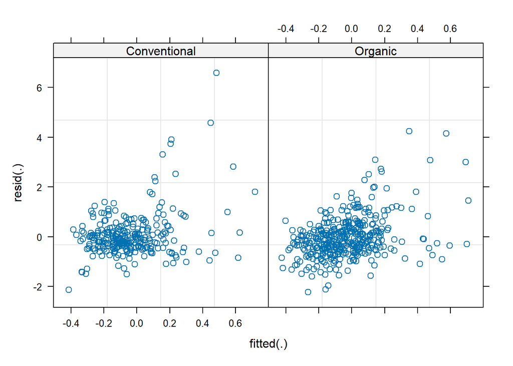

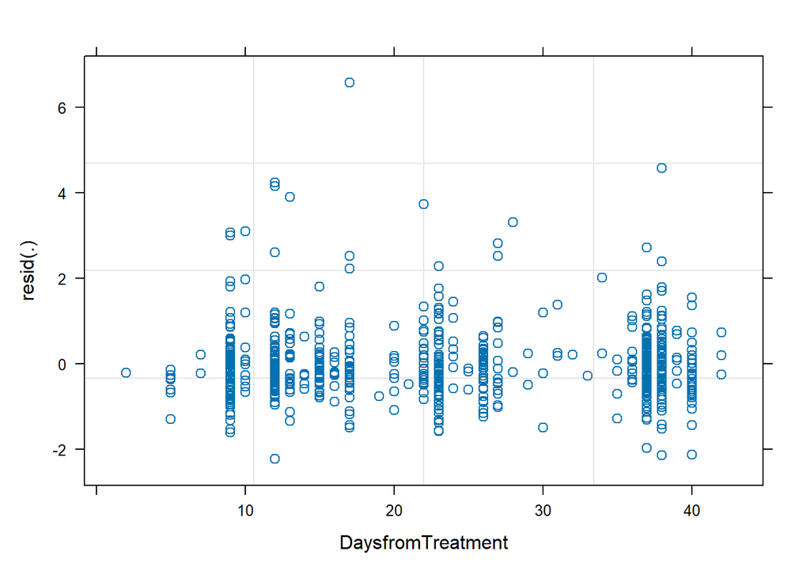

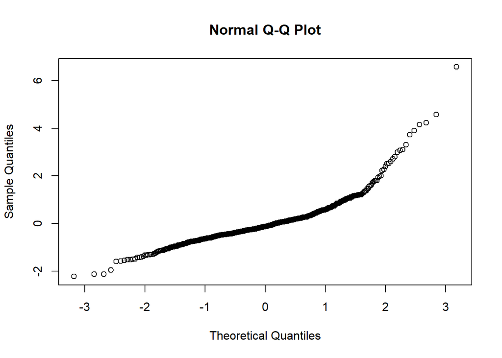

### Log creatinine adjusted CRP ~ Log creatinine adjusted baseline CRP + creatinine adjusted 3-PBA + DaysfromTreatment + sex + baseline age + random(…)

logadj_crp_S_BL + adj_pb1000_S + DaysfromTreatment + Sex + age_baseline_S + (1 | ID)

|  | logadj crp S TR |  |  |
| --- | --- | --- | --- |
| Predictors | Estimates | CI | p |
| (Intercept) | -0.053 | -0.241 – 0.134 | 0.578 |
| logadj crp S BL | 0.040 | -0.038 – 0.118 | 0.319 |
| adj pb1000 S | 0.104 | 0.035 – 0.173 | **0.003** |
| DaysfromTreatment | -0.000 | -0.006 – 0.005 | 0.880 |
| Sex [Female] | 0.021 | -0.163 – 0.205 | 0.823 |
| age baseline S | -0.008 | -0.101 – 0.084 | 0.857 |
| Random Effects |  |  |  |
| σ<sup>2</sup> | 0.75 |  |  |
| τ<sub>00</sub> <sub>ID</sub> | 0.15 |  |  |
| ICC | 0.17 |  |  |
| N <sub>ID</sub> | 146 |  |  |
| Observations | 681 |  |  |
| Marginal R<sup>2</sup> / Conditional R<sup>2</sup> | 0.014 / 0.181 |  |  |

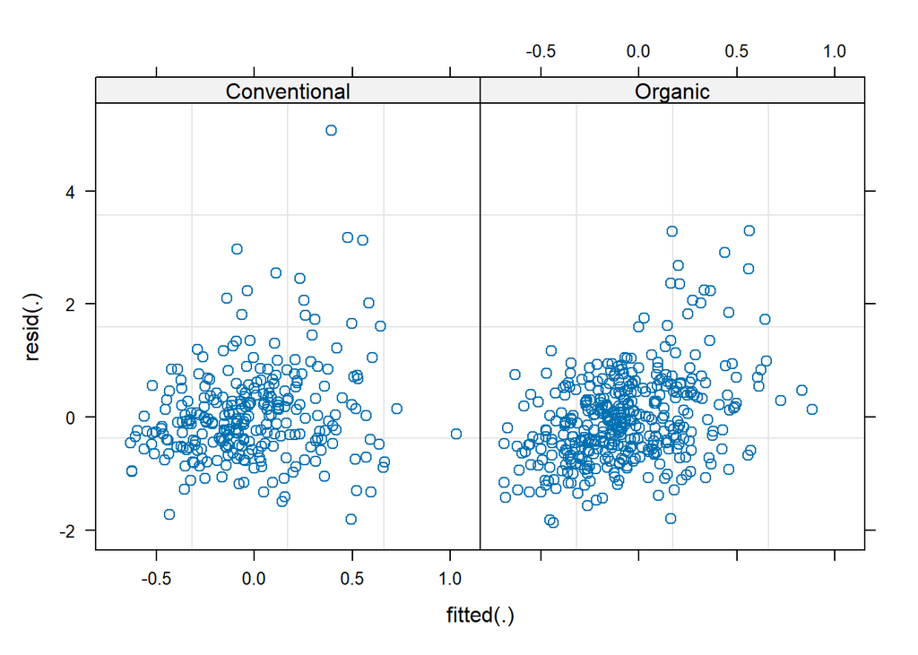

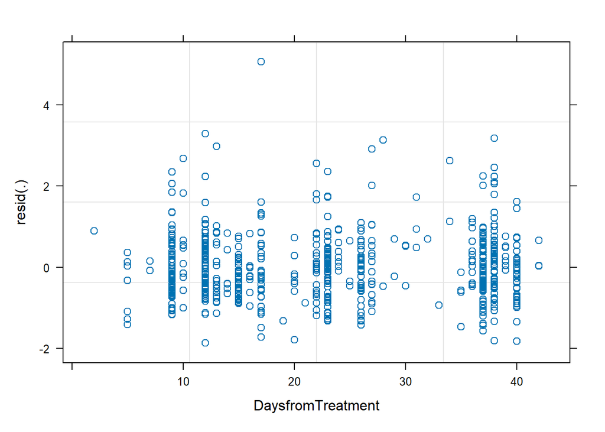

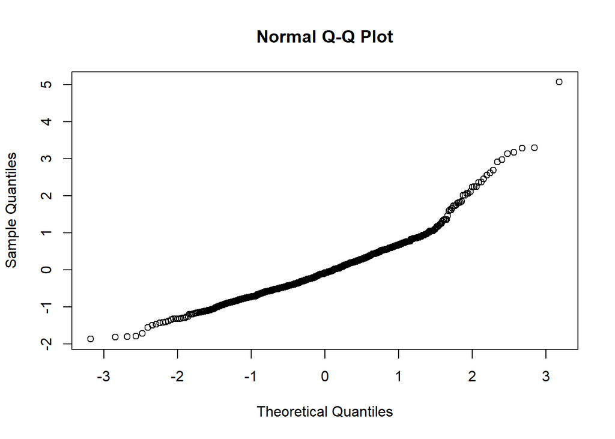